# TP3: Classification with genetic markers

## 3. Linear discriminant analysis

### (a)

LDA- linear discriminant analysis uses both x and y axes to project the data onto a 1-D graph in 2 ways using the linear discriminant function :

1. It uses the mean values of the classes and maximizes the distance between them.
2. It uses variation minimization in both the classes for separation.

If using the mean values linear discriminant analysis algorithm method the then the average values are deduced and used while the variations within the class itself are minimized. The newly generated axes between data-points separate the 2 classes effectively.

However, if the distribution’s mean values are shared between the classes, Linear Discriminant Analysis cannot find a new linearly separable axis causing the LDA method to fail which is one of the disadvantages of linear discriminant analysis. In such cases, one will have to use the method of non-linear discriminant analysis to separate the 2 classes during classification.

LDA works when all the independent/predictor variables are continuous (not categorical) and follow a Normal distribution.

We will see the performance of LDA in classifying our dataset:

```r
library(MASS)
lda_data = cbind(contID = NAcont[,c(1)], pca$x)
lda_data = data.frame(lda_data)

lda_data[2:ncol(lda_data)] <- scale(lda_data[2:ncol(lda_data)])
# apply(lda_data[2:ncol(lda_data)], 2, mean)
# apply(lda_data[2:ncol(lda_data)], 2, sd)
lda_data = data.frame(lda_data)

contLDA <- lda(contID~.,data = lda_data, tol = 1e-25)
contLDA.p <- predict(contLDA)$class
table(contLDA.p, NAcont$contID)
```

```
##
## contLDA.p NorthAmerica CentralAmerica SouthAmerica
##         1           67              0            0
##         2            0            159            0
##         3            0              0          268
```

```r
print(contLDA$svd^2 / sum(contLDA$svd^2))
```

```
## [1] 9.899629e-01 1.003715e-02 8.204539e-33
```

```r
#contLDA
```

The singular values are analogous to the eigenvalues of the Principal Component Analysis, except that LDA does not maximize the variance of a component, instead it maximizes the separability (defined by the between and within-group standard deviation). Thus, the “proportion of trace” is the proportion of between-class variance that is explained by successive discriminant functions. Hence, 98.99% of the between-class variance is explained by the first linear discriminant function.

Now, Calculating the optimal number of PCAs for LDA.

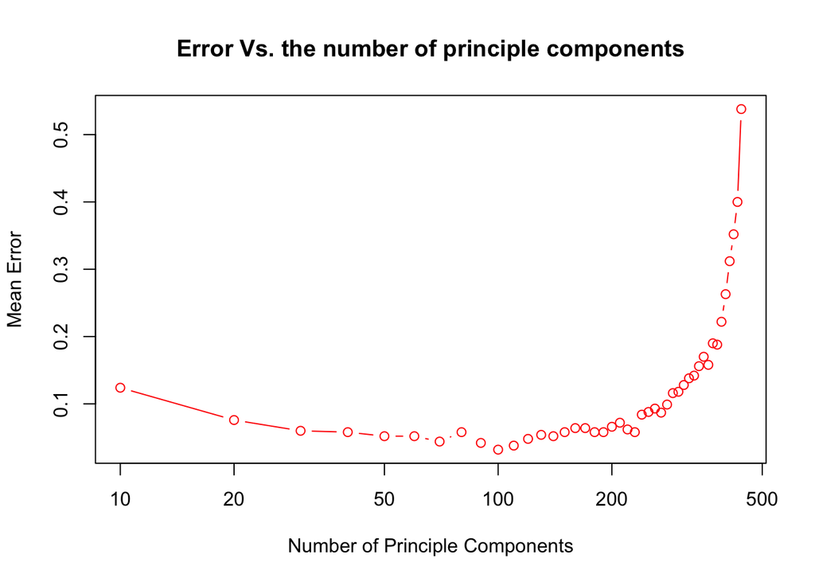

```r
plot(naxes, test_error, col = "red",log="x",type = 'b',xlab="Number of Principle Components",ylab="Mean Error",main="Error Vs. the number of principle components")
```

Choosing the interval (90,115) to calculate the optimal number of components

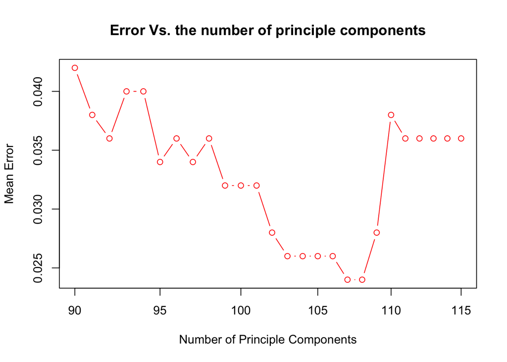

```r
plot(naxes2, test_error2, col = "red",log="x",type='b',xlab="Number of Principle Components",ylab="Mean Error",main="Error Vs. the number of principle components")
```

```r
reg = lda(NAcont$contID~pca$x[,1:107])
#xtabs(~predict(reg)+NAcont$contID, data = NAcont)
table(predict(reg)$class, NAcont$contID)
```

```
##
##                  NorthAmerica CentralAmerica SouthAmerica
##   NorthAmerica             67              0            0
##   CentralAmerica            0            155            0
##   SouthAmerica              0              4          268
```

```r
print(reg$svd^2 / sum(reg$svd^2))
```

```
## [1] 0.669601 0.330399
```

## 4. Naive Bayes

### (a)

** Since there is a problem with loading naiveBayes function, we comment these code. **  
Naïve Bayes is a classification method based on Bayes’ theorem that derives the probability of the given feature vector being associated with a label. Naïve Bayes has a naive assumption of conditional independence for every feature, which means that the algorithm expects the features to be independent which not always is the case. we will discover if this is the case in our data.

```r
# library(naivebayes)
# bayes_data <- cbind(contID = NAcont[,c(1)], pca$x)
# bayes_data <- data.frame(bayes_data)
# bayes <- naiveBayes(contID~.,data = bayes_data)
# table(predict(bayes,bayes_data), bayes_data[,1])
```

```r
# set.seed(3)
# labels = rep (1:10 , each =50)
# set = sample(labels ,494)
#
# naxes = seq(10, 440, by=10)
#
#  test_error = rep(0, length(naxes))
#  for (j in 1:length(naxes)){
#    sum = 0
#    for (i in c(1:10)){
#      train_subset = bayes_data[which(set!=i), c(1,2:naxes[j]+1)]
#      test_subset = bayes_data[which(set==i), c(1,2:naxes[j]+1)]
#      train <- lda(contID~., data = train_subset)
#      test <- predict(train,newdata = test_subset)$class
#      tab <- table(test, test_subset[,1])
#      #print(tab)
#      error = 1-round((sum(diag(tab))/sum(tab)),2)
# #     print(error)
#      sum = sum+error
#    }
#    test_error[j] = sum/10
#  }
#  plot(naxes, test_error, col = "red",log="x",type = 'b',xlab="Number of Principle Components",ylab="Mean Error",main="Error Vs. the number of principle components")
#
#
# naxes2 = seq(90, 110, by=1)
# test_error2 = rep(0, length(naxes2))
# for (j in 1:length(naxes2)){
#   sum = 0
#   for (i in c(1:10)){
#     train_subset = bayes_data[which(set!=i), c(1,2:naxes2[j]+1)]
#     test_subset = bayes_data[which(set==i), c(1,2:naxes2[j]+1)]
#     train <- lda(contID~., data = train_subset)
#     test <- predict(train,newdata = test_subset)$class
#     tab <- table(test, test_subset[,1])
#     #print(tab)
#     error = 1-round((sum(diag(tab))/sum(tab)),2)
#     #print(error)
#     sum = sum+error
#   }
#   test_error2[j] = sum/10
# }
# plot(naxes2, test_error2, col = "red",log="x",type='b',xlab="Number of Principle Components",ylab="Mean Error",main="Error Vs. the number of principle components")
#
```

```r
# naxes2[which.min(test_error2)]
```

```r
# bayesData = cbind(contID = NAcont[,c(1)], pca$x[,1:107])
# bayesData = data.frame(bayesData)
# # nacont = cbind(contID=NAcont[,c(1)], pca$x)
# bayes <-naiveBayes(contID~., data = bayesData)
# tab<-table(predict(bayes,bayesData), bayesData[,1])
# mean(predict(bayes,bayesData) == bayesData[,1])
# error = 1-round((sum(diag(tab))/sum(tab)),2)
# print(error)
```

## Conclusion

In the beginning of each section, we talked about how each classifier works, and now we want to compare the result we obtained using the genetic data :